# RClass11_MLR

### 상호작용(Interaction) 효과

- 한 변수의 효과가 다른 변수의 값(value) 또는 수준(level)에 따라 달라지는 현상
- R에서는 두 변수가 `x`, `y`일 때, `x:y`로 나타낸다.

### R에서 공식(formula)으로 선형 모형을 나타내는 방법

- Wilkson-Rogers Notation

| 표기 | 표기2 | 수식 |
| --- | --- | --- |
| `y ~ x1 + x2` | `y~1+x1+x2` | $\mathbb{E}[\mathbf{y}] = \beta_0 + \beta_1 \mathbf{x1} + \beta_2 \mathbf{x2}$ |
| `y ~ x1 + x2 - 1` | `y~x1+x2` | $\mathbb{E}[\mathbf{y}] = \phantom{\beta_0+} \beta_1 \mathbf{x1} + \beta_2 \mathbf{x2}$ |
| `y ~ x1:x2` | `y~1+x1:x2` | $\mathbb{E}[\mathbf{y}] = \beta_0 + \beta_1 (\mathbf{x1}\cdot\mathbf{x2})$ |
| `y ~ x1*x2` | `y~1+x1+x2+x1:x2` | $\mathbb{E}[\mathbf{y}] = \beta_0 + \beta_1 \mathbf{x1} +\beta_2 \mathbf{x2} + \beta_3 (\mathbf{x1}\cdot\mathbf{x2})$ |
| `y ~ I(x1*x2)` | `z=x1*x2; y~1+z` | $\mathbb{E}[\mathbf{y}] = \beta_0 + \beta_1 (\mathbf{x1}\cdot\mathbf{x2})$ |
| `y ~ (x1 + x2)^2 - x1` | `y~1+x2+x1:x2` | $\mathbb{E}[\mathbf{y}] = \beta_0 + \beta_1(\mathbf{x2})+\beta_2 (\mathbf{x2}\cdot\mathbf{x2})$ |

### 두 선형 모형을 평가하기

- 적합도와 모형의 복잡도를 함께 고려한 평가 지수
  - AIC(Akake Information Criterion) : `aic(fit)`
  - BIC(Bayesian Information Criterion) : `aic(fit, k=log(nrow(fit$model))`
- 예측 능력 평가
  - 검증 데이터에서 실제 $y$와 예측된 $y$의 차이
    - 평균제곱오차(MSE; Mean Squared Error) : $\frac{\sum{(\hat{y_i}-y_i)^2}}{n}$
    - 제곱근평균제곱오차(RMSE; Root Mean Squared Error) : $\sqrt{\frac{(\sum{\hat{y_i}-y_i)^2}}{n}}$
    - 평균절대오차(MAE; Mean Absolute Error) : $\frac{\sum{|\hat{y_i}-y_i|}}{n}$
  - 결정계수(the coefficient of determination) : $R^2 = \mathbb{C}or(y, \hat{y})^2 = \frac{\mathbb{V}\text{ar}[y]-\text{MSE}}{\mathbb{V}\text{ar}[y]}$
- 내포된 두 모형 비교
  - 항이 더 많은 모형이 항상 설명력이 더 높다(동일한 설명변수 값에 대해 결정계수가 더 크다).
  - `anova`를 통해 설명력이 유의미하게 높은지 검정이 가능하다.

### 범주형 변수에 대한 선형 회귀 분석(3개 이상의 범주일 때)

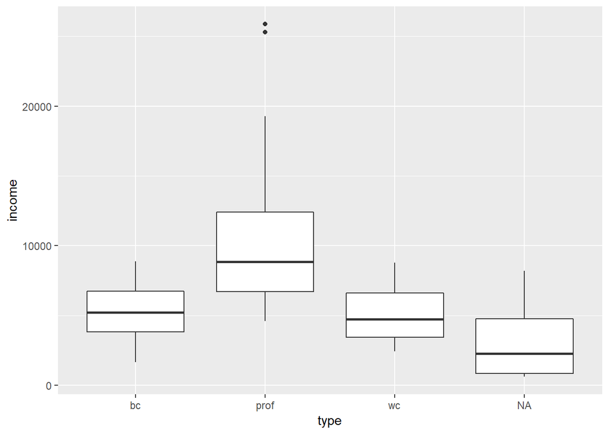

```r
# Prestige Data
library(ggplot2)
Prestige <- carData::Prestige

ggplot(Prestige, aes(x=type, y=income)) + geom_boxplot()
```

```r
fitPrestige <- lm(income ~ type, data=Prestige)
summary(fitPrestige)
```

```
##
## Call:
## lm(formula = income ~ type, data = Prestige)
##
## Residuals:
##     Min      1Q  Median      3Q     Max
## -5945.5 -2003.3  -466.2  1536.9 15319.5
##
## Coefficients:
##             Estimate Std. Error t value Pr(>|t|)
## (Intercept)   5374.1      521.8  10.299  < 2e-16 ***
## typeprof      5185.3      811.6   6.389 6.16e-09 ***
## typewc        -321.8      890.6  -0.361    0.719
## ---
## Signif. codes:  0 '***' 0.001 '**' 0.01 '*' 0.05 '.' 0.1 ' ' 1
##
## Residual standard error: 3461 on 95 degrees of freedom
##   (4 observations deleted due to missingness)
## Multiple R-squared:  0.3437, Adjusted R-squared:  0.3299
## F-statistic: 24.87 on 2 and 95 DF,  p-value: 2.057e-09
```

```r
#fitaov <- aov(income ~ type, data=Prestige)
#summary(fitaov)

modelmat <- model.matrix(~ type, data=Prestige)
modelmat[c(1,28,31),]  # prof, bc, wc
```

```
##                     (Intercept) typeprof typewc
## gov.administrators            1        1      0
## nursing.aides                 1        0      0
## medical.technicians           1        0      1
```

```r
fitPrestige2 <- lm(income ~ type -1, data=Prestige) # type + 0
summary(fitPrestige2)
```

```
##
## Call:
## lm(formula = income ~ type - 1, data = Prestige)
##
## Residuals:
##     Min      1Q  Median      3Q     Max
## -5945.5 -2003.3  -466.2  1536.9 15319.5
##
## Coefficients:
##          Estimate Std. Error t value Pr(>|t|)
## typebc     5374.1      521.8   10.30  < 2e-16 ***
## typeprof  10559.5      621.7   16.99  < 2e-16 ***
## typewc     5052.3      721.7    7.00  3.6e-10 ***
## ---
## Signif. codes:  0 '***' 0.001 '**' 0.01 '*' 0.05 '.' 0.1 ' ' 1
##
## Residual standard error: 3461 on 95 degrees of freedom
##   (4 observations deleted due to missingness)
## Multiple R-squared:  0.8236, Adjusted R-squared:  0.818
## F-statistic: 147.9 on 3 and 95 DF,  p-value: < 2.2e-16
```

```r
modelmat2 <- model.matrix(~ type -1, data=Prestige)
modelmat2[c(1,28,31),]  # prof, bc, wc
```

```
##                     typebc typeprof typewc
## gov.administrators       0        1      0
## nursing.aides            1        0      0
## medical.technicians      0        0      1
```

### 예측 모형(Predictive Model)과 구조 모형(Structural Model)

- 구조 모형
  - 원인-결과 모형
  - 한 변수를 변화시킬 때 나타나는 효과를 추정할 수 있다.
- 예측 모형
  - 주어진 관찰값으로 결과 변수의 값을 예측하기 위한 모형
  - 계수 해석 : 다른 예측 변수가 고정되어 있을 때, 주어진 예측 변수가 1 더 큰 사례에 대한 결과변수 평균의 증가량

```r
# 01. age -> iq
#         -> footsize
print(getwd())
```

```
## [1] "C:/R/project1/project1/MJU-2018-02-DataScience/00_Instructor/W12_LogisticRegression"
```

```r
library(car)
datIQ <- read.csv('./data_iq.csv', row.names=1)
fitA <- lm(iq ~ age, datIQ)
fitB <- lm(iq ~ age + footsize, datIQ)
summary(fitA)
```

```
##
## Call:
## lm(formula = iq ~ age, data = datIQ)
##
## Residuals:
##     Min      1Q  Median      3Q     Max
## -7.5151 -2.0862 -0.3031  2.0271  7.9076
##
## Coefficients:
##             Estimate Std. Error t value Pr(>|t|)
## (Intercept)   1.6308     1.2441   1.311    0.193
## age           9.8342     0.1175  83.722   <2e-16 ***
## ---
## Signif. codes:  0 '***' 0.001 '**' 0.01 '*' 0.05 '.' 0.1 ' ' 1
##
## Residual standard error: 2.994 on 98 degrees of freedom
## Multiple R-squared:  0.9862, Adjusted R-squared:  0.9861
## F-statistic:  7009 on 1 and 98 DF,  p-value: < 2.2e-16
```

```r
summary(fitB)
```

```
##
## Call:
## lm(formula = iq ~ age + footsize, data = datIQ)
##
## Residuals:
##     Min      1Q  Median      3Q     Max
## -7.4147 -1.8826 -0.1914  2.0271  8.1366
##
## Coefficients:
##             Estimate Std. Error t value Pr(>|t|)
## (Intercept)   1.3739     1.2582   1.092    0.278
## age          11.7031     1.5222   7.688 1.23e-11 ***
## footsize     -0.1234     0.1002  -1.231    0.221
## ---
## Signif. codes:  0 '***' 0.001 '**' 0.01 '*' 0.05 '.' 0.1 ' ' 1
##
## Residual standard error: 2.987 on 97 degrees of freedom
## Multiple R-squared:  0.9864, Adjusted R-squared:  0.9861
## F-statistic:  3524 on 2 and 97 DF,  p-value: < 2.2e-16
```

```r
compareCoefs(fitA, fitB)
```

```
## Calls:
## 1: lm(formula = iq ~ age, data = datIQ)
## 2: lm(formula = iq ~ age + footsize, data = datIQ)
##
##             Model 1 Model 2
## (Intercept)    1.63    1.37
## SE             1.24    1.26
##
## age           9.834  11.703
## SE            0.117   1.522
##
## footsize             -0.123
## SE                    0.100
##
```

```r
anova(fitA, fitB)
```

```
## Analysis of Variance Table
##
## Model 1: iq ~ age
## Model 2: iq ~ age + footsize
##   Res.Df    RSS Df Sum of Sq      F Pr(>F)
## 1     98 878.72
## 2     97 865.19  1    13.526 1.5164 0.2211
```

```r
fitA <- lm(footsize ~ age, datIQ)
fitB <- lm(footsize ~ age + iq, datIQ)
summary(fitA)
```

```
##
## Call:
## lm(formula = footsize ~ age, data = datIQ)
##
## Residuals:
##    Min     1Q Median     3Q    Max
## -8.031 -2.066 -0.160  1.559  8.946
##
## Coefficients:
##             Estimate Std. Error t value Pr(>|t|)
## (Intercept)  -2.0807     1.2505  -1.664   0.0993 .
## age          15.1415     0.1181 128.245   <2e-16 ***
## ---
## Signif. codes:  0 '***' 0.001 '**' 0.01 '*' 0.05 '.' 0.1 ' ' 1
##
## Residual standard error: 3.01 on 98 degrees of freedom
## Multiple R-squared:  0.9941, Adjusted R-squared:  0.994
## F-statistic: 1.645e+04 on 1 and 98 DF,  p-value: < 2.2e-16
```

```r
summary(fitB)
```

```
##
## Call:
## lm(formula = footsize ~ age + iq, data = datIQ)
##
## Residuals:
##     Min      1Q  Median      3Q     Max
## -8.1950 -2.0181 -0.2896  1.7194  9.2040
##
## Coefficients:
##             Estimate Std. Error t value Pr(>|t|)
## (Intercept)  -1.8773     1.2581  -1.492    0.139
## age          16.3679     1.0028  16.322   <2e-16 ***
## iq           -0.1247     0.1013  -1.231    0.221
## ---
## Signif. codes:  0 '***' 0.001 '**' 0.01 '*' 0.05 '.' 0.1 ' ' 1
##
## Residual standard error: 3.002 on 97 degrees of freedom
## Multiple R-squared:  0.9942, Adjusted R-squared:  0.994
## F-statistic:  8267 on 2 and 97 DF,  p-value: < 2.2e-16
```

```r
compareCoefs(fitA, fitB)
```

```
## Calls:
## 1: lm(formula = footsize ~ age, data = datIQ)
## 2: lm(formula = footsize ~ age + iq, data = datIQ)
##
##             Model 1 Model 2
## (Intercept)   -2.08   -1.88
## SE             1.25    1.26
##
## age          15.141  16.368
## SE            0.118   1.003
##
## iq                   -0.125
## SE                    0.101
##
```

```r
anova(fitA, fitB)
```

```
## Analysis of Variance Table
##
## Model 1: footsize ~ age
## Model 2: footsize ~ age + iq
##   Res.Df    RSS Df Sum of Sq      F Pr(>F)
## 1     98 887.79
## 2     97 874.12  1    13.665 1.5164 0.2211
```

```r
# 02. taste -> score <- interior
datScore <- read.csv('./data_taste.csv', row.names=1)
fitA <- lm(taste ~ score, dat=datScore)
fitB <- lm(taste ~ score + interior, data=datScore)
fitC <- lm(taste ~ score*interior, data=datScore)
compareCoefs(fitA, fitB, fitC)
```

```
## Calls:
## 1: lm(formula = taste ~ score, data = datScore)
## 2: lm(formula = taste ~ score + interior, data = datScore)
## 3: lm(formula = taste ~ score * interior, data = datScore)
##
##                Model 1  Model 2  Model 3
## (Intercept)      1.624    2.786    0.681
## SE               0.456    0.493    1.627
##
## score           0.5624   0.7694   1.1543
## SE              0.0834   0.0895   0.2972
##
## interior               -0.37148 -0.00161
## SE                      0.08357  0.28494
##
## score:interior                   -0.0646
## SE                                0.0476
##
```

```r
anova(fitA, fitB, fitC)
```

```
## Analysis of Variance Table
##
## Model 1: taste ~ score
## Model 2: taste ~ score + interior
## Model 3: taste ~ score * interior
##   Res.Df    RSS Df Sum of Sq       F   Pr(>F)
## 1     98 188.16
## 2     97 156.32  1    31.841 19.9299 2.19e-05 ***
## 3     96 153.37  1     2.943  1.8421   0.1779
## ---
## Signif. codes:  0 '***' 0.001 '**' 0.01 '*' 0.05 '.' 0.1 ' ' 1
```

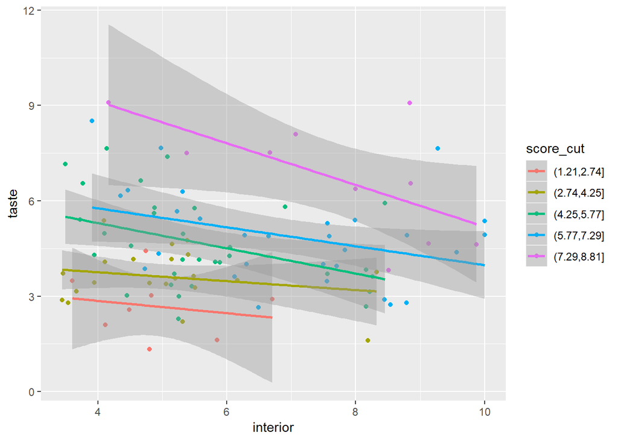

```r
datScore$score_cut <- cut(datScore$score, breaks=5)

library(ggplot2)
ggplot(datScore, aes(x=interior, y=taste, col=score_cut)) + geom_point() +
  geom_smooth(method='lm')
```

### 예측변수가 범주형 변수와 연속형 변수인 경우

```r
# Prestige Data
library(ggplot2)
Prestige <- carData::Prestige
cat('#### Prestige 데이터 : education=연속형 변수, type=범주형 변수')
```

```
## #### Prestige 데이터 : education=연속형 변수, type=범주형 변수
```

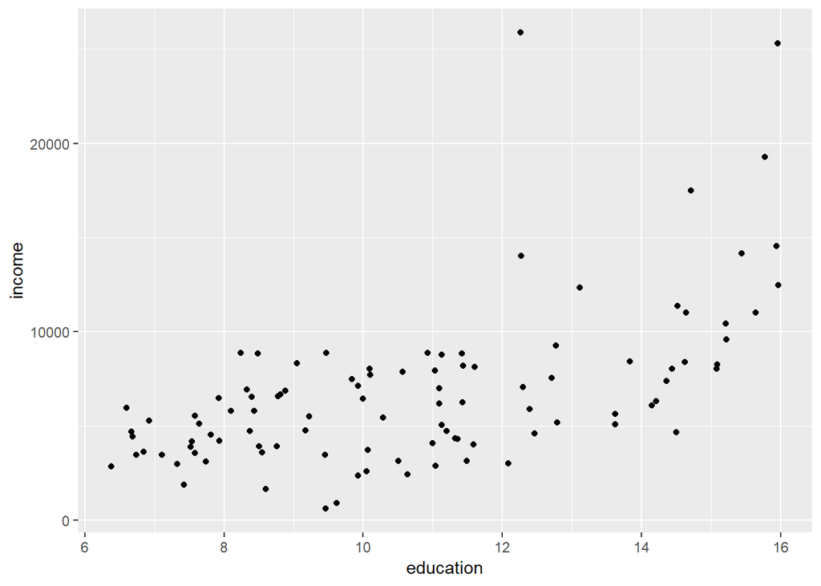

```r
ggplot(Prestige, aes(x=education, y=income)) + geom_point()
```

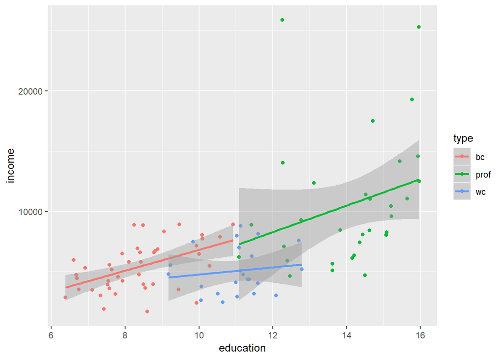

```r
Prestige %>% filter(complete.cases(Prestige)) %>%
  ggplot(aes(x=education, y=income, col=type)) +
  geom_point() +
  geom_smooth(method="lm")
```

```r
fit <- lm(income ~ type + education, Prestige)
summary(fit)
```

```
##
## Call:
## lm(formula = income ~ type + education, data = Prestige)
##
## Residuals:
##     Min      1Q  Median      3Q     Max
## -6242.7 -1768.0  -408.3  1149.1 16939.3
##
## Coefficients:
##             Estimate Std. Error t value Pr(>|t|)
## (Intercept)  -2048.2     2431.5  -0.842  0.40171
## typeprof       102.1     1805.3   0.057  0.95501
## typewc       -2685.8     1140.5  -2.355  0.02061 *
## education      887.9      284.7   3.119  0.00241 **
## ---
## Signif. codes:  0 '***' 0.001 '**' 0.01 '*' 0.05 '.' 0.1 ' ' 1
##
## Residual standard error: 3312 on 94 degrees of freedom
##   (4 observations deleted due to missingness)
## Multiple R-squared:  0.4052, Adjusted R-squared:  0.3862
## F-statistic: 21.35 on 3 and 94 DF,  p-value: 1.249e-10
```

### 문제

- `00_Instructor/Davis.txt`을 불러 읽은 후 자료를 plot하고 보고된 체중과 실제 체중의 관계에 대해 분석하세요.

### 이상치(Outlier) 또는 영향점(influential point)에 대한 대처법

1. 여러 가지 근거로 데이터가 정확한지 확인한다
   - 의외로 실수로 잘못 입력된 경우가 많다. 여러 가지 정황으로 고칠 수 있다면 고친다. 그럴 수 없다면 삭제한다.
   - 정확하다면 관찰값을 이해하고자 노력해본다. 해당 사례에는 특별한 이유가 있을 수 있다. 특별한 사례라면 따로 다룬다.
2. 모형을 다시 만들어 본다.
   - 상호작용을 포함해서 새로운 변수가 필요할 수도 있다. 특별한 사례라면 그것을 나타내는 지시변수를 생각해볼 수 있다.
   - 예측 변수 또는 결과 변수를 변환해 본다. 변환된 변수에는 이상치 또는 영향점이 아닐 수 있다.
3. 강건한(robust) 방법을 사용한다.
   - 강건한 방법은 오차 분산(error variance)가 정규분포가 아닐 때에도 효율적인 추정이 가능하다. 이때 이상치는 비중가 축소된다. 하지만 영향점에 대해서는 해결이 불가능하다.

## 다중 회귀 분석에 나타날 수 있는 문제점과 해결책

### 너무 많은 예측 변수 또는 다중공선성(Multicollinearity)

- 관찰 사례보다 예측 변수의 수가 비슷하거나 많으면 모수 추정이 불안정하거나 불가능하다.
- 예측 변수의 수가 많아지면 과적합이 일어나서 예측이 부정확해진다.
- 변수 사이에 다중공선성이 있을 경우에 계수 추정이 불안정하거나 불가능하다. R에서 `car::vif` 함수로 다중공선성의 존재 여부를 판단할 수 있다.
- 대처 방법
  - 상관계수가 높은 두 변수의 경우 둘의 가중치 합을 새로운 변수로 사용하거나, 한 변수를 제거할 수 있다.
  - 분산이 너무 작거나, 범주가 너무 치우쳐서 예측에 도움이 되지 않는 변수는 제거한다.
  - 주성분분석(pca; principal component analysis)와 같은 차원축소(dimension reduction)방법을 먼저 실시한다.

### 문제

- `carData::Anscombe`을 `lm(income~education+young+urban, dat)`을 했을 때 다중 공선성 문제를 진단하세요. 그리고 모든 상호작용항을 포함시킨 모형에 대해서도 다중공선성 문제를 진단하세요.

### 예

- 미국 프로야구 선수의 연봉 예측하기(`BaseballHitters.csv`)

### 비선형적인 독립변수-종속변수 관계(Nonlinear functional form)

- 예측변수 또는 결과변수를 변환(transform)한다.
  - `log(x), 1/x, sqrt(x), x, x^2, exp(x)`
  - `log(y), 1/y, sqrt(y), y, y^2, exp(y)`
- 비선형적 함수 관계를 자동으로 찾아주는 방법
  - 예) 평활 스플라인(smoothing spline) 회귀, 일반화가법모형(gam; generalized additive model)

### 비선형적이고 상호작용효과가 동시에 존재할 경우

- 회귀나무(Regression Tree) 또는 인공신경망(Artificial Neural Network)을 사용할 수 있다.

### 과적합의 예

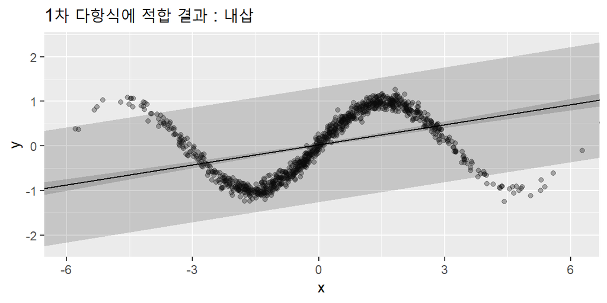

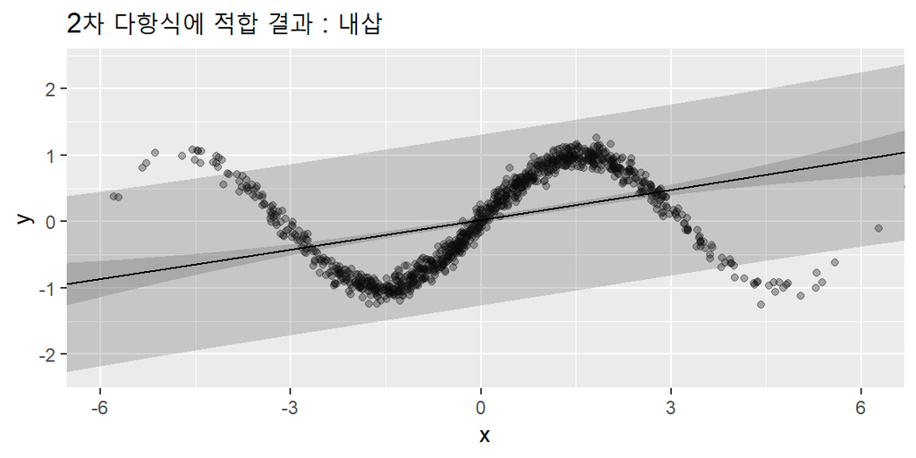

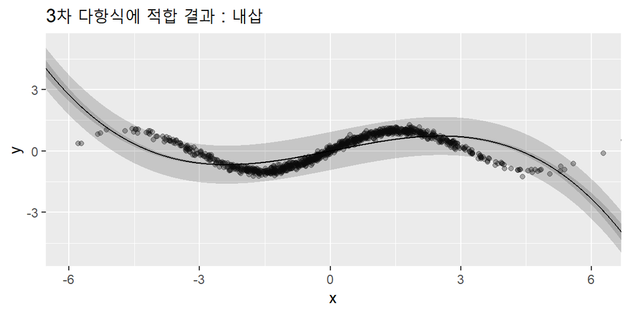

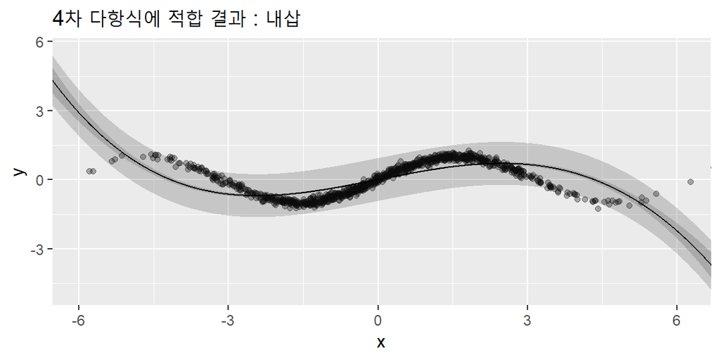

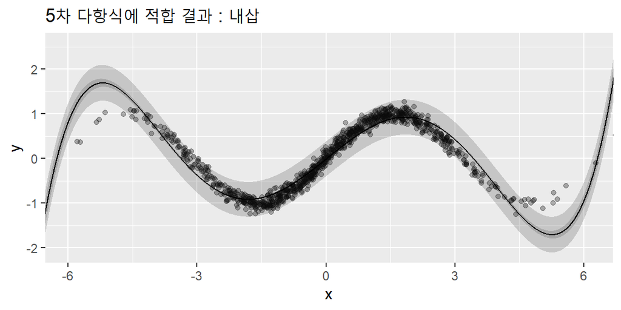

[output not shown]

[output not shown]

[output not shown]

[output not shown]

[output not shown]

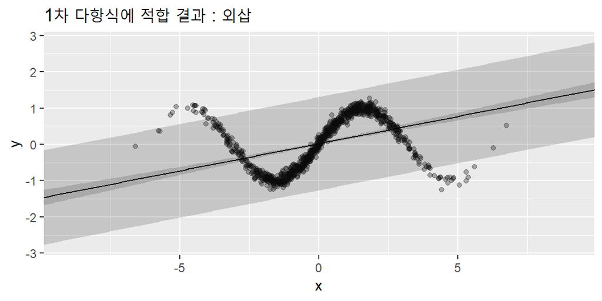

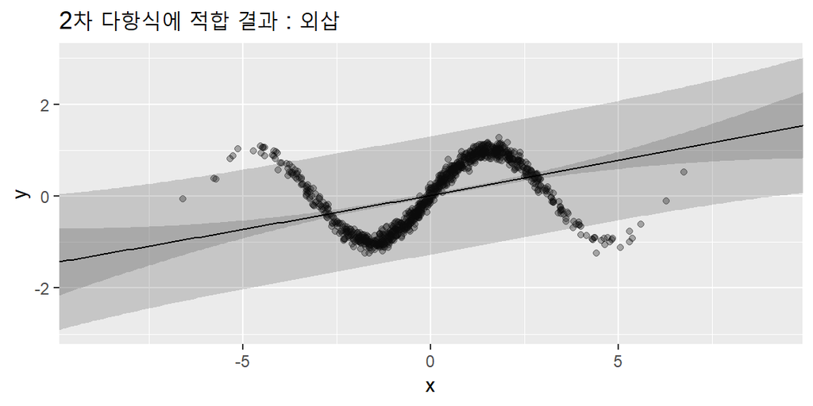

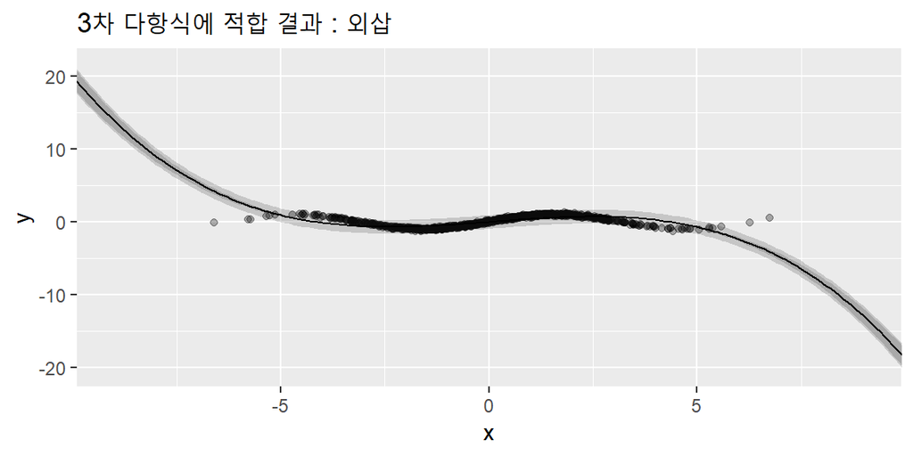

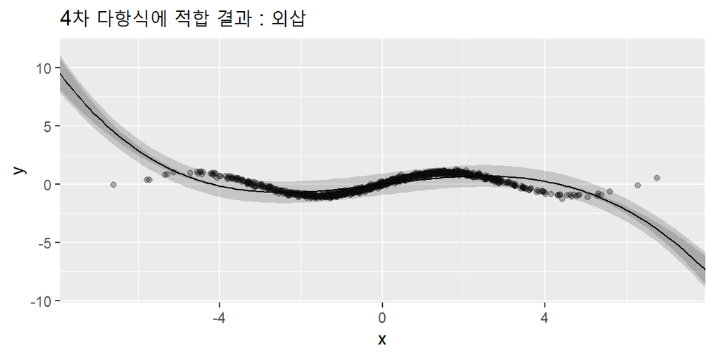

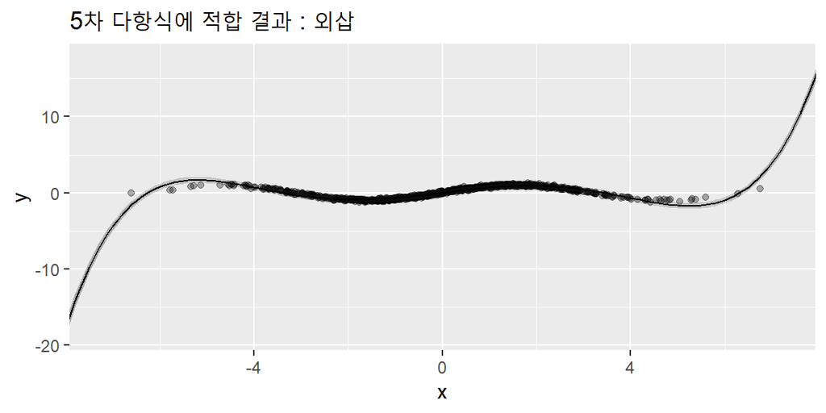

[output not shown]

[output not shown]

[output not shown]

[output not shown]

[output not shown]

### 정리

- 모형 : $y= \beta_0 + \beta_1 x_1 + \beta_2 x_2 + ... + \beta_p x_p + e, e \sim \mathcal{N}(0, \sigma^2)$
- 가정
  - **L**inearity
  - **I**ndependence
  - **N**ormality
  - **E**qual Variance
- R을 활용한 다중 선형 회귀 분석
  - 적합 : `lm`
  - 공식(formula) : `y ~ x1 + x2 + x3`, `y ~ x1:x2`, `y ~ x1*x2`, `y ~ I(x1^2)`, …
  - 계수 : `coef`
  - 신뢰구간 : `confint`
- 적합된 선형 모형의 평가
  - 결정계수(coefficient of determination) : $R^2$
  - 잔차의 제곱평균(MSE), 절대평균(MAE)
- 예측 모형과 원인결과 모형의 구분
- 설명 변수와 결과 변수의 함수 관계를 나타내는 용어
  - 비선형적 효과
  - 상호작용 효과
- 선형 회귀 분석에서 주의할 점
  - 이상치(outlier)와 영향점(influential point)
  - 다중공선성(multi-collinearity)